# atmo

## 1. Identification des inversions thermiques en Utilisant les données de temperature :

#### Différence de température (température maximale - température minimale)

```r
# Calculer la différence de température
df$diff_temp <- df$temperature_max - df$temperature_min

# Résumé statistique et distribution
summary(df$diff_temp)
```

```
   Min. 1st Qu.  Median    Mean 3rd Qu.    Max.
  0.000   1.500   4.400   5.765   9.400  22.300
```

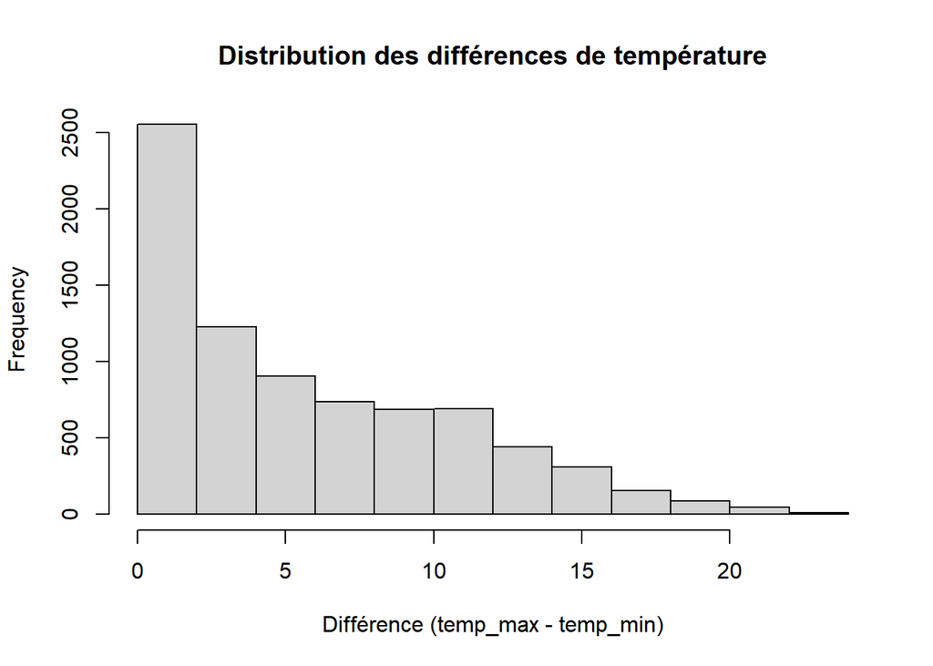

```r
hist(df$diff_temp, main = "Distribution des différences de température",
     xlab = "Différence (temp_max - temp_min)")
```

#### Définition du seuil d’inversion thermique

```r
# Définir un seuil basé sur l'analyse descriptive
seuil <- 5  # Exemple de seuil
df$inversion <- ifelse(df$diff_temp > seuil, "Oui", "Non")

# Fréquence des inversions thermiques
table(df$inversion)
```

```
 Non  Oui
4243 3609
```

Sur les 7852 observations, 3609 (46%) présentent une inversion thermique (différence de température supérieure à 5°C), tandis que 4243 (54%) n’en présentent pas. Cela suggère que les inversions thermiques sont des phénomènes relativement fréquents, ce qui souligne leur importance pour l’analyse des pics de pollution.

#### Statistiques descriptives par inversion thermique

```r
# Calcul des moyennes et écarts-types par groupe
statistiques_polluants <- df %>%
  group_by(inversion) %>%
  summarise(
    mean_NO2 = mean(NO2, na.rm = TRUE),
    sd_NO2 = sd(NO2, na.rm = TRUE),
    mean_PM10 = mean(PM10, na.rm = TRUE),
    sd_PM10 = sd(PM10, na.rm = TRUE),
    mean_O3 = mean(O3, na.rm = TRUE),
    sd_O3 = sd(O3, na.rm = TRUE)
  )

print(statistiques_polluants)
```

```
# A tibble: 2 × 7
  inversion mean_NO2 sd_NO2 mean_PM10 sd_PM10 mean_O3 sd_O3
  <chr>        <dbl>  <dbl>     <dbl>   <dbl>   <dbl> <dbl>
1 Non           7.16   5.73      11.0    6.35    41.2  24.5
2 Oui           7.30   7.53      12.0    8.39    61.3  26.1
```

Les résultats montrent que les inversions thermiques ont un impact notable sur les niveaux de pollution atmosphérique :

- **NO2** : La concentration moyenne de NO2 est légèrement plus élevée lors des inversions thermiques (7.30 µg/m³) comparée aux périodes sans inversion (7.16 µg/m³). De plus, l’écart-type augmente également, passant de 5.73 à 7.53, indiquant une plus grande variabilité pendant les inversions.
- **PM10** : Une augmentation plus marquée est observée pour les PM10, avec une moyenne de 12.00 µg/m³ en période d’inversion, contre 10.96 µg/m³ sans inversion. L’écart-type augmente également, reflétant une dispersion plus importante des particules fines.
- **O3** : Les niveaux moyens d’O3 sont significativement plus élevés lors des inversions thermiques (61.31 µg/m³) que sans inversion (41.18 µg/m³). Cette différence, associée à une légère augmentation de l’écart-type (de 24.53 à 26.10), suggère que les inversions favorisent l’accumulation d’ozone, probablement à cause de la stagnation de l’air.

#### Interprétation :

Les inversions thermiques créent des conditions atmosphériques favorisant l’accumulation de polluants, en particulier des particules fines et de l’ozone. Cela peut s’expliquer par la faible dispersion des polluants dans une atmosphère stratifiée, un phénomène typique des inversions.